# Model Selection 2

## Presentations

## Updates

- 10 minutes each instead of 15.
- Friday presentations can go over a bit.
- Remember: everyone must speak
- Rehearsal: OH Thursday, Sunday afternoon 3 - 4:30

## Morning Schedule

**Friday**

- Akchheta, Celine, Sara
- Alison, Emily, Melissa
- Shanda, Shelbie, Sylvia

**Monday**

- Cleo, Grace, Yujia
- Dana, Jung, Rose
- Caiyun, Milani, Prarthana
- Amanda, Buyan, Michelle
- Jacqui, Melissa, Whitney
- Allie, Emily, Sibonelo

## Afternoon Schedule

**Friday**

- Kelu, Siyao, Siying
- Arda, David, Thalia
- Claire, Mahima, Van

**Monday**

- Annakate, Emma, Sam
- Amna, Anne, Nikita
- Fei, Steph, Tu
- Danni, Kate, Thao
- Anne, Liz, Rebecca
- Bharati, Ma'ame, Meher

## Exam

## Exam parameters

- Anything in the notes (slides + boardwork) or HW is fair game.
- MC + short answer
- Emphasis on full holistic analysis from research question to conclusion in context.
- One 3.5" by 5" notecard allowed.
- Practice problems on Friday.
- Recommended homework (not collected): Chapter 7, exercise 3.

## Model Selection II

## Searching the model space

[figure not shown]

For a given data set with many potential predictors, there exists many possible models.

How should we systematically evaluate those models?

## A diagram

## Model search strategies

1. All best subsets
2. Backwards elimination
3. Forward selection
- Note that each method may choose a different model!

## Example: Bridge Building

[figure not shown]

## The data

```r
bridge <- read.table("http://www.stat.tamu.edu/~sheather/book/docs/datasets/bridge.txt", header=TRUE)
head(bridge)
```

```
##   Case  Time DArea CCost Dwgs Length Spans
## 1    1  78.8  3.60  82.4    6     90     1
## 2    2 309.5  5.33 422.3   12    126     2
## 3    3 184.5  6.29 179.8    9     78     1
## 4    4  69.6  2.20 100.0    5     60     1
## 5    5  68.8  1.44 103.0    5     60     1
## 6    6  95.7  5.40 134.4    5     60     1
```

## All best subsets

```r
logDArea <- log(bridge$DArea)
logCCost <- log(bridge$CCost)
logDwgs <- log(bridge$Dwgs)
logLength <- log(bridge$Length)
logSpans <- log(bridge$Spans)
X <- cbind(logDArea,logCCost,logDwgs,logLength,logSpans)
library(leaps)
b <- regsubsets(as.matrix(X), log(bridge$Time))
summary(b)$outmat
```

```
##          logDArea logCCost logDwgs logLength logSpans
## 1  ( 1 ) " "      " "      "*"     " "       " "
## 2  ( 1 ) " "      " "      "*"     " "       "*"
## 3  ( 1 ) " "      "*"      "*"     " "       "*"
## 4  ( 1 ) "*"      "*"      "*"     " "       "*"
## 5  ( 1 ) "*"      "*"      "*"     "*"       "*"
```

## Build best models

```r
summary(b)$outmat
```

```
##          logDArea logCCost logDwgs logLength logSpans
## 1  ( 1 ) " "      " "      "*"     " "       " "
## 2  ( 1 ) " "      " "      "*"     " "       "*"
## 3  ( 1 ) " "      "*"      "*"     " "       "*"
## 4  ( 1 ) "*"      "*"      "*"     " "       "*"
## 5  ( 1 ) "*"      "*"      "*"     "*"       "*"
```

```r
m1 <- lm(log(bridge$Time) ~ logDwgs)
m2 <- lm(log(bridge$Time) ~ logDwgs + logSpans)
m3 <- lm(log(bridge$Time) ~ logDwgs + logSpans + logCCost)
m4 <- lm(log(bridge$Time) ~ logDwgs + logSpans + logCCost + logDArea)
m5 <- lm(log(bridge$Time) ~ logDwgs + logSpans + logCCost + logDArea + logLength)
models <- list(m1, m2, m3, m4, m5)
```

## Compare best models

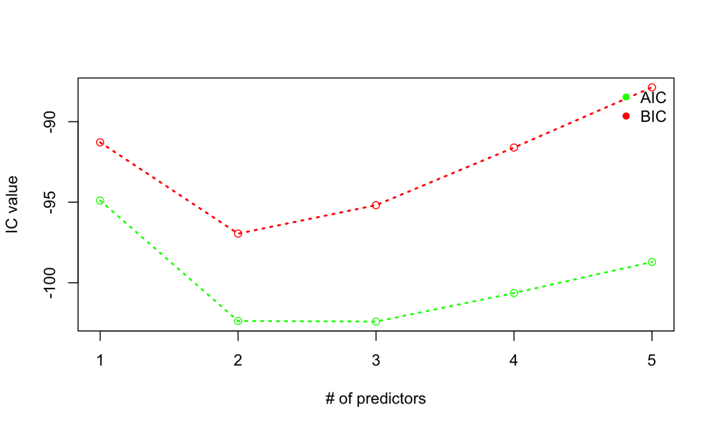

## Comparing best models

```r
summary(m2)$coef
```

```
##             Estimate Std. Error t value  Pr(>|t|)
## (Intercept)   2.6617    0.26871   9.905 1.489e-12
## logDwgs       1.0416    0.15420   6.755 3.259e-08
## logSpans      0.2853    0.09095   3.137 3.116e-03
```

```r
summary(m3)$coef
```

```
##             Estimate Std. Error t value  Pr(>|t|)
## (Intercept)   2.3317     0.3577   6.519 7.902e-08
## logDwgs       0.8356     0.2135   3.914 3.356e-04
## logSpans      0.1963     0.1107   1.773 8.371e-02
## logCCost      0.1483     0.1075   1.380 1.752e-01
```

## Comparing best models

The two and the three predictor model both do well, but the two predictor model is preferred because of the statistical significance of the predictors.

*Be aware that when looking at p-values of many many models, the burden of proof should be much higher. That is, we need very low p-values to be convinced of statistical significance*.

## Backward elimination

```r
backAIC <- step(m5, direction = "backward", data = bridge)
```

```
## Start:  AIC=-98.71
## log(bridge$Time) ~ logDwgs + logSpans + logCCost + logDArea +
##     logLength
##
##             Df Sum of Sq  RSS    AIC
## - logLength  1     0.006 3.85 -100.6
## - logDArea   1     0.013 3.86 -100.6
## <none>                   3.84  -98.7
## - logCCost   1     0.182 4.03  -98.6
## - logSpans   1     0.266 4.11  -97.7
## - logDwgs    1     1.454 5.30  -86.3
##
## Step:  AIC=-100.6
## log(bridge$Time) ~ logDwgs + logSpans + logCCost + logDArea
##
##            Df Sum of Sq  RSS    AIC
## - logDArea  1     0.020 3.87 -102.4
## <none>                  3.85 -100.6
## - logCCost  1     0.181 4.03 -100.6
## - logSpans  1     0.315 4.16  -99.1
## - logDwgs   1     1.449 5.30  -88.3
##
## Step:  AIC=-102.4
## log(bridge$Time) ~ logDwgs + logSpans + logCCost
##
##            Df Sum of Sq  RSS    AIC
## <none>                  3.87 -102.4
## - logCCost  1     0.180 4.05 -102.4
## - logSpans  1     0.297 4.17 -101.1
## - logDwgs   1     1.445 5.31  -90.1
```

```r
backBIC <- step(m5, direction = "backward", data = bridge, k = log(nrow(bridge)))
```

```
## Start:  AIC=-87.87
## log(bridge$Time) ~ logDwgs + logSpans + logCCost + logDArea +
##     logLength
##
##             Df Sum of Sq  RSS   AIC
## - logLength  1     0.006 3.85 -91.6
## - logDArea   1     0.013 3.86 -91.5
## - logCCost   1     0.182 4.03 -89.6
## - logSpans   1     0.266 4.11 -88.7
## <none>                   3.84 -87.9
## - logDwgs    1     1.454 5.30 -77.2
##
## Step:  AIC=-91.61
## log(bridge$Time) ~ logDwgs + logSpans + logCCost + logDArea
##
##            Df Sum of Sq  RSS   AIC
## - logDArea  1     0.020 3.87 -95.2
## - logCCost  1     0.181 4.03 -93.4
## - logSpans  1     0.315 4.16 -91.9
## <none>                  3.85 -91.6
## - logDwgs   1     1.449 5.30 -81.0
##
## Step:  AIC=-95.19
## log(bridge$Time) ~ logDwgs + logSpans + logCCost
##
##            Df Sum of Sq  RSS   AIC
## - logCCost  1     0.180 4.05 -97.0
## - logSpans  1     0.297 4.17 -95.7
## <none>                  3.87 -95.2
## - logDwgs   1     1.445 5.31 -84.7
##
## Step:  AIC=-96.95
## log(bridge$Time) ~ logDwgs + logSpans
##
##            Df Sum of Sq  RSS   AIC
## <none>                  4.05 -97.0
## - logSpans  1      0.95 5.00 -91.3
## - logDwgs   1      4.40 8.45 -67.7
```

## Forward selection

```r
mint <- lm(log(Time) ~ 1, data = bridge)
forwardAIC <- step(mint,
                   scope = list(lower = ~1, upper = ~log(DArea) + log(CCost) +
                                  log(Dwgs) + log(Length) + log(Spans)),
                   direction = "forward", data = bridge)
```

```
## Start:  AIC=-41.35
## log(Time) ~ 1
##
##               Df Sum of Sq   RSS   AIC
## + log(Dwgs)    1     12.18  5.00 -94.9
## + log(CCost)   1     11.61  5.56 -90.1
## + log(DArea)   1     10.29  6.88 -80.5
## + log(Length)  1     10.01  7.16 -78.7
## + log(Spans)   1      8.73  8.45 -71.3
## <none>                     17.17 -41.3
##
## Step:  AIC=-94.9
## log(Time) ~ log(Dwgs)
##
##               Df Sum of Sq  RSS    AIC
## + log(Spans)   1     0.949 4.05 -102.4
## + log(CCost)   1     0.832 4.17 -101.1
## + log(Length)  1     0.669 4.33  -99.4
## + log(DArea)   1     0.476 4.52  -97.4
## <none>                     5.00  -94.9
##
## Step:  AIC=-102.4
## log(Time) ~ log(Dwgs) + log(Spans)
##
##               Df Sum of Sq  RSS  AIC
## + log(CCost)   1    0.1796 3.87 -102
## <none>                     4.05 -102
## + log(DArea)   1    0.0185 4.03 -101
## + log(Length)  1    0.0169 4.03 -101
##
## Step:  AIC=-102.4
## log(Time) ~ log(Dwgs) + log(Spans) + log(CCost)
##
##               Df Sum of Sq  RSS  AIC
## <none>                     3.87 -102
## + log(DArea)   1    0.0196 3.85 -101
## + log(Length)  1    0.0129 3.86 -101
```

```r
forwardBIC <- step(mint,
                   scope = list(lower = ~1, upper = ~log(DArea) + log(CCost) +
                                  log(Dwgs) + log(Length) + log(Spans)),
                   direction = "forward", data = bridge,k = log(nrow(bridge)))
```

```
## Start:  AIC=-39.54
## log(Time) ~ 1
##
##               Df Sum of Sq   RSS   AIC
## + log(Dwgs)    1     12.18  5.00 -91.3
## + log(CCost)   1     11.61  5.56 -86.5
## + log(DArea)   1     10.29  6.88 -76.9
## + log(Length)  1     10.01  7.16 -75.1
## + log(Spans)   1      8.73  8.45 -67.7
## <none>                     17.17 -39.5
##
## Step:  AIC=-91.28
## log(Time) ~ log(Dwgs)
##
##               Df Sum of Sq  RSS   AIC
## + log(Spans)   1     0.949 4.05 -97.0
## + log(CCost)   1     0.832 4.17 -95.7
## + log(Length)  1     0.669 4.33 -93.9
## + log(DArea)   1     0.476 4.52 -92.0
## <none>                     5.00 -91.3
##
## Step:  AIC=-96.95
## log(Time) ~ log(Dwgs) + log(Spans)
##
##               Df Sum of Sq  RSS   AIC
## <none>                     4.05 -97.0
## + log(CCost)   1    0.1796 3.87 -95.2
## + log(DArea)   1    0.0185 4.03 -93.4
## + log(Length)  1    0.0169 4.03 -93.3
```

## Stepwise compared

**Backward Elimination**

Optimal model based on AIC included `log(CCost)`, `log(Dwgs)`, and `log(Spans)`. Optimal model based on BIC included only `log(Dwgs)` and `log(Spans)`.

**Forward Selection**

Using AIC, the optimal model is the same as by backward AIC. Using BIC, the optimal model is the same as backward BIC.

*We have the same choice between the 2 and 3 predictor models.*

## Activity

## Activity 9

Build a full model (with no transformations) to the `Haldcement.txt` file from the book's website to predict the Y using all of the X's.

1. Identify the optimal model(s) using all possible subsets and AIC/BIC.
2. Identify the optimal model(s) using backward elimination and AIC/BIC.
3. Identify the optimal model(s) using forward selection and AIC/BIC.
4. Do the methods agree on the optimal model? If not, why not?
5. Recommend a final model and provide your reasoning.